# MontyHall

Danilo Steckelberg

8/31/2020

## Monty Hall

O problema de Monty Hall vem do famoso programa em que as pessoas poderiam escolher entre 3 portas, e, após a escolha, uma delas é revelada ao participante. O participante pode, então, escolher entre trocar ou não a porta. Embora pareça que o participante tenha 50% de chance de ganhar ao trocar a porta, uma vez que há duas portas, uma com prêmio, outra sem prêmio, a chance é significativamente maior se ele trocar de porta.

Para averiguar, desenvolvi a função abaixo, que simula um problema de Monty Hall com *n* portas (n >= 3), e que faça quantas simulações se queira. Há também 3 modelos de escolha de troca de porta: 1) “aleatorio”, em que a escolha de troca ocorre aleatoriamente, com 50% de chance de trocar ou não de porta; 2) “troca”, em que o participante sempre troca de porta; 3) “nao_troca”, em que o participante nunca troca de porta.

```r
MontyHall <- function(simulacoes = 100, nPortas = 3, modeloTroca = "aleatorio"){
  for(i in 1:simulacoes){
    Portas <- c(1:nPortas)
    Premio <- sample(Portas,1)
    Escolha <- sample(Portas,1)

    # Quais portas estão disponíveis para serem abertas: excluir a porta com prêmio e a porta escolhida.
    PortasDisponiveis <- Portas[-c(Premio,Escolha)]

    # Se apenas uma porta for disponível, escolher esta porta. Se duas portas estiverem disponíveis,
    # escolher aleatoriamente entre as duas.
    if(length(PortasDisponiveis) == 1){
      PortasReveladas <- PortasDisponiveis
    }else{
        PortasReveladas <- sample(PortasDisponiveis,(nPortas-2))
    }

    # Portas finais que ficam disponíveis para o participante escolher
    PortasFinais <- Portas[-c(PortasReveladas)]

    # Modelos de troca para o participante:
    # 1) "troca" ele sempre trocará;
    # 2) "nao_troca" ele nunca trocará;
    # 3) "aleatorio" ele troca de acordo com uma probabilidade aleatoria.

    if(modeloTroca == "aleatorio"){
      Troca <- ifelse(runif(1)>=0.5,1,0)
    }
    if(modeloTroca == "troca"){
      Troca <- 1
    }
    if(modeloTroca == "nao_troca"){
      Troca <- 0
    }


    # Rotina para troca ou não troca das portas.
    if(Troca == 1){
      PortaEscolhida <- PortasFinais[PortasFinais != Escolha]
    }else{
      PortaEscolhida <- PortasFinais[PortasFinais == Escolha]
    }

    if(PortaEscolhida == Premio){Vitoria = 1}else{Vitoria = 0}

    if(i == 1){
      Resultados <- data.frame(EscolhaInicial = Escolha, EscolhaFinal = PortaEscolhida, Premio = Premio, Troca = Troca, Vitoria = Vitoria)
    }else{
      Resultados <- rbind(Resultados,data.frame(EscolhaInicial = Escolha, EscolhaFinal = PortaEscolhida, Premio = Premio, Troca = Troca, Vitoria = Vitoria))
    }
  }
  return(Resultados)
}
```

## Simulação e plotagem de resultados

Segue abaixo uma simulação com 1000 casos e 3 portas, no modelo de troca aleatório:

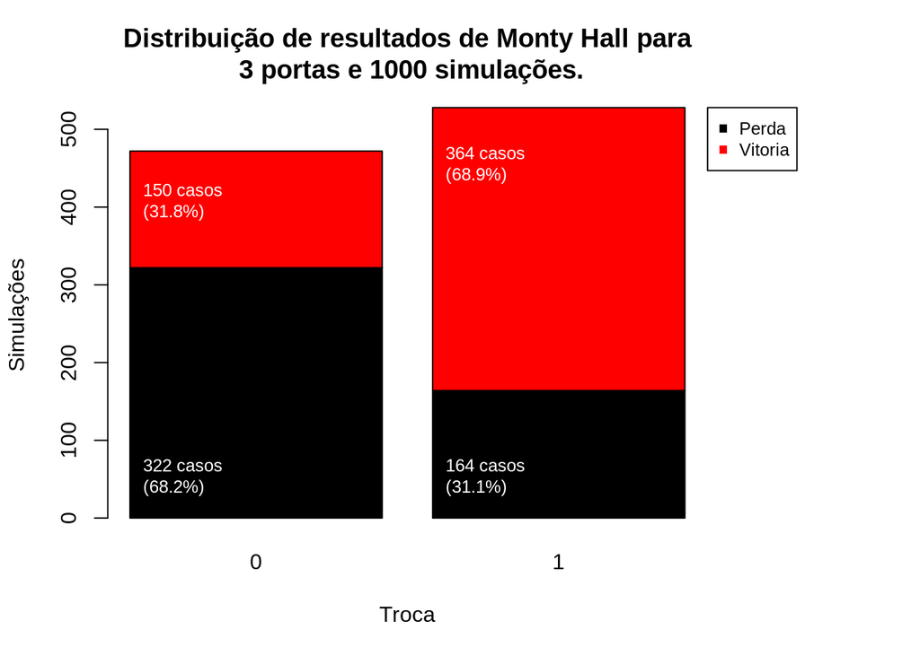

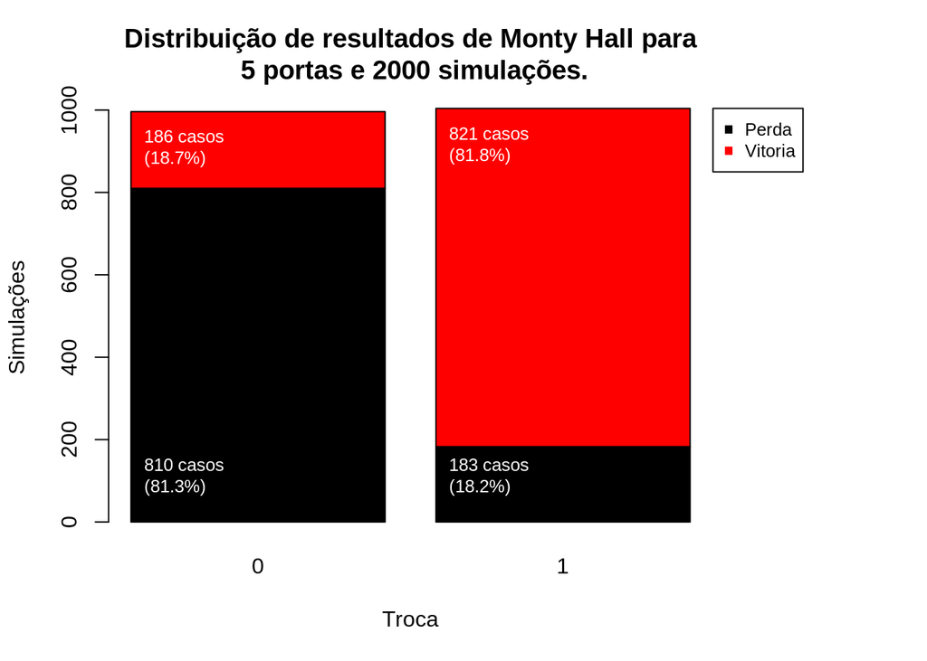